# Lab 3

Zichen Men

## Problem 1: Expected Values of Investments

A venture capitalist is considering three different investment opportunities. We are tasked with calculating the expected value of each investment to assist in decision-making.

### Investment A (Software Company)

Investment A has the following profit probabilities: - A 9% chance of returning $7,000,000 profit - A 39% chance of returning $2,000,000 profit - A 52% chance of losing $1,000,000

```r
# Defining the values and probabilities for Investment A
values_A <- c(7000000, 2000000, -1000000)
probabilities_A <- c(0.09, 0.39, 0.52)

# Calculating the expectation for Investment A
expectation_A <- sum(values_A * probabilities_A)
expectation_A
```

```
## [1] 890000
```

### Investment B (Hardware Company)

Investment B has the following profit probabilities: - A 10% chance of returning $11,000,000 profit - A 43% chance of returning $2,000,000 profit - A 47% chance of losing $1,000,000

```r
# Defining the values and probabilities for Investment B
values_B <- c(11000000, 2000000, -1000000)
probabilities_B <- c(0.10, 0.43, 0.47)

# Calculating the expectation for Investment B
expectation_B <- sum(values_B * probabilities_B)
expectation_B
```

```
## [1] 1490000
```

### Investment C (Biotech Firm)

Investment C has the following profit probabilities: - A 15% chance of returning $5,000,000 profit - An 18% chance of no profit or loss ($0) - A 67% chance of losing $1,000,000

```r
# Defining the values and probabilities for Investment C
values_C <- c(5000000, 0, -1000000)
probabilities_C <- c(0.15, 0.18, 0.67)

# Calculating the expectation for Investment C
expectation_C <- sum(values_C * probabilities_C)
expectation_C
```

```
## [1] 80000
```

## Problem 2: Multiple Choice Quiz Probabilities

Robin has to guess the answers in a multiple choice quiz consisting of 5 questions, each with 4 options (a, b, c, d). We calculate the probabilities for various scenarios regarding her guesses:

### (a) Probability the first question she gets right is the 3rd question

```r
# Each question has a 1/4 chance of being correct, and she must get the first two wrong.
prob_a <- (3/4)^2 * (1/4)
prob_a
```

```
## [1] 0.140625
```

### (b) Probability she gets exactly 3 or exactly 4 questions right

```r
# Using binomial distribution to find the probabilities for exactly 3 and exactly 4 correct answers
prob_b3 <- dbinom(3, size = 5, prob = 1/4)
prob_b4 <- dbinom(4, size = 5, prob = 1/4)
prob_b_total <- prob_b3 + prob_b4
prob_b_total
```

```
## [1] 0.1025391
```

### (c) Probability she gets the majority of the questions right

```r
# "Majority" means more than half, so 3 or more out of 5
prob_c <- sum(dbinom(3:5, size = 5, prob = 1/4))
prob_c
```

```
## [1] 0.1035156
```

### Exponential Distribution Example

```r
# Demonstrating exponential distribution functions
pexp_0_4_lower <- pexp(0.4, 4, lower.tail = TRUE)
pexp_0_4_upper <- pexp(0.4, 4, lower.tail = FALSE)
qexp_0_8 <- qexp(0.8, 4, lower.tail = TRUE)
random_exp_values <- rexp(5, 4)
pexp_0_4_lower
```

```
## [1] 0.7981035
```

```r
pexp_0_4_upper
```

```
## [1] 0.2018965
```

```r
qexp_0_8
```

```
## [1] 0.4023595
```

```r
random_exp_values
```

```
## [1] 0.03301628 0.93758348 0.22136455 0.39378165 0.03667934
```

## Problem 3: Analogue Signal Analysis

We analyze an analogue signal measured at a detector, which follows a normal distribution with a mean of 200 microvolts and a variance of 256.

### (a) Probability the signal exceeds 224 μV

```r
prob_a <- pnorm(224, mean = 200, sd = 16, lower.tail = FALSE)
prob_a
```

```
## [1] 0.0668072
```

### (b) Probability the signal is between 186 μV and 224 μV

```r
prob_b <- pnorm(224, mean = 200, sd = 16) - pnorm(186, mean = 200, sd = 16)
prob_b
```

```
## [1] 0.7424058
```

### (c) Microvoltage below which 25% of the signals are

```r
quantile_c <- qnorm(0.25, mean = 200, sd = 16)
quantile_c
```

```
## [1] 189.2082
```

### (d) Probability signal is less than 240 μV, given it’s greater than 210 μV

```r
prob_d <- (pnorm(240, mean = 200, sd = 16) - pnorm(210, mean = 200, sd = 16)) / pnorm(240, mean = 200, sd = 16, lower.tail = FALSE)
prob_d
```

```
## [1] 41.83412
```

### (e) Estimate the interquartile range

```r
IQR_estimate <- qnorm(0.75, mean = 200, sd = 16) - qnorm(0.25, mean = 200, sd = 16)
IQR_estimate
```

```
## [1] 21.58367
```

### (f) Probability signal is less than 220 μV, given it’s greater than 210 μV

```r
prob_f <- (pnorm(220, mean = 200, sd = 16) - pnorm(210, mean = 200, sd = 16)) / pnorm(220, mean = 200, sd = 16, lower.tail = FALSE)
prob_f
```

```
## [1] 1.517616
```

### (g) Probability a signal > 200 μV is in fact > 220 μV

```r
prob_g <- pnorm(220, mean = 200, sd = 16, lower.tail = FALSE) / pnorm(200, mean = 200, sd = 16, lower.tail = FALSE)
prob_g
```

```
## [1] 0.2112995
```

## Problem 4: Dice Game Earnings Analysis

Given a dice game with specific payouts and penalties, we will analyze the expected outcomes and variance in winnings.

### (a) Probability Distribution Table for X and P(X)

```r
# Define the earnings and their probabilities
earnings <- c(-8, 5, 10)
probabilities <- c(3/6, 3/6, 1/6)  # Outcomes: 1,2; 3,4,5; 6

# Create a probability distribution table
probability_distribution <- data.frame(Earnings = earnings, Probability = probabilities)
probability_distribution
```

```
##   Earnings Probability
## 1       -8   0.5000000
## 2        5   0.5000000
## 3       10   0.1666667
```

### (b) Expected Winning Calculation using a For Loop

```r
# Calculate expected winnings using a for loop
expected_winnings <- 0
for (i in 1:length(earnings)) {
  expected_winnings <- expected_winnings + earnings[i] * probabilities[i]
}
expected_winnings
```

```
## [1] 0.1666667
```

### (c) Variance of Winning Calculation using a For Loop

```r
# Calculate variance of winnings using a for loop
mean_winnings <- expected_winnings
variance_winnings <- 0
for (i in 1:length(earnings)) {
  variance_winnings <- variance_winnings + probabilities[i] * (earnings[i] - mean_winnings)^2
}
variance_winnings
```

```
## [1] 61.14352
```

### (d) Simulation of 20 Independent People Playing the Game

```r
# Simulation of 20 people playing the game
set.seed(2024)  # Setting a random seed for reproducibility
simulated_winnings <- replicate(20, sum(sample(earnings, size = 1, prob = probabilities, replace = TRUE)))
total_winnings <- sum(simulated_winnings)
total_winnings
```

```
## [1] 3
```

## Problem 5: Hypergeometric Distribution in Quality Control

An office supply store manager checks a box of 23 pens, including 5 defective ones. The manager selects 3 pens randomly.

### (a) Probability Distribution for the Number of Defective Pens

```r
total_pens <- 23
defective_pens <- 5
selected_pens <- 3

# X values: 0 to minimum(selected_pens, defective_pens)
x_values <- 0:min(selected_pens, defective_pens)
# Calculating the probabilities
probabilities <- dhyper(x_values, defective_pens, total_pens - defective_pens, selected_pens)
data.frame(X = x_values, Probability = probabilities)
```

```
##   X Probability
## 1 0 0.460756635
## 2 1 0.431959345
## 3 2 0.101637493
## 4 3 0.005646527
```

### (b) Expected Number of Defective Pens

```r
expected_defectives <- sum(x_values * probabilities)
expected_defectives
```

```
## [1] 0.6521739
```

### (c) Expected Value from Hypergeometric Formula

```r
expected_formula <- selected_pens * defective_pens / total_pens
expected_formula
```

```
## [1] 0.6521739
```

## Problem 6: Law of Large Numbers Illustration

### (a) Averaging Geometric Random Variables

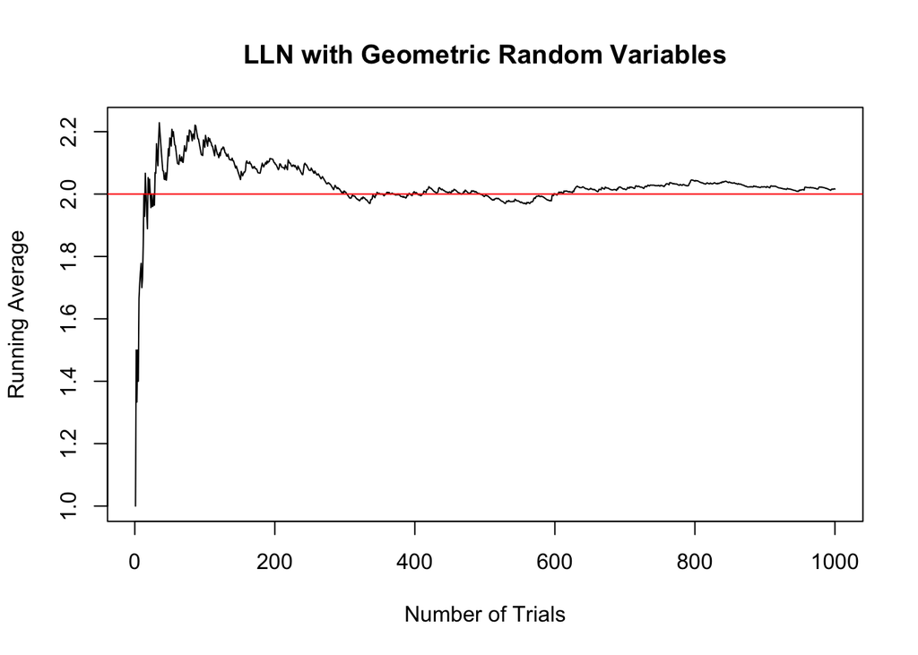

```r
# Illustrating LLN with geometric random variables
set.seed(2024)  # Ensuring reproducibility
n <- 1000  # Number of random variables
p <- 0.5   # Probability of success
geometric_vars <- rgeom(n, prob = p) + 1  # Geometric distribution starts at 1
average_geometric <- cumsum(geometric_vars) / (1:n)
plot(average_geometric, type = 'l', main = "LLN with Geometric Random Variables", xlab = "Number of Trials", ylab = "Running Average")
abline(h = 1/p, col = "red")
```

### (b) Averaging Exponential Random Variables

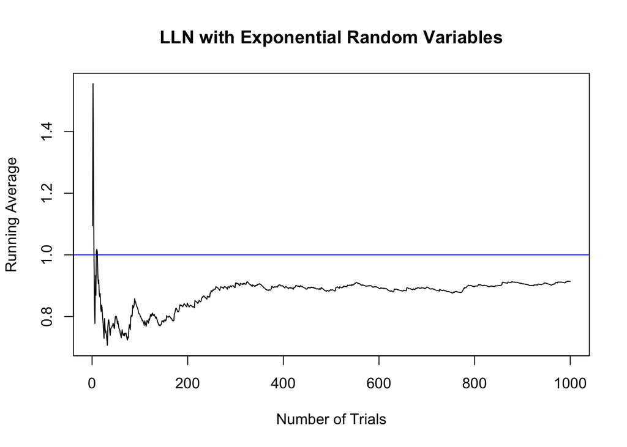

```r
# Illustrating LLN with exponential random variables
lambda <- 1  # Rate parameter
exponential_vars <- rexp(n, rate = lambda)
average_exponential <- cumsum(exponential_vars) / (1:n)
plot(average_exponential, type = 'l', main = "LLN with Exponential Random Variables", xlab = "Number of Trials", ylab = "Running Average")
abline(h = 1/lambda, col = "blue")
```

## Problem 7: Central Limit Theorem Demonstrations

### (a) Geometric Random Variables

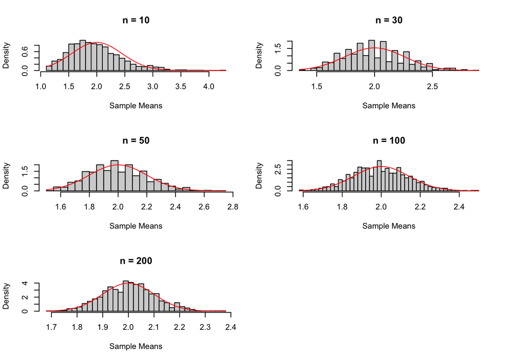

```r
set.seed(2024)  # Ensuring reproducibility
samples <- 1000  # Number of samples for each graph
sample_size <- c(10, 30, 50, 100, 200)  # Different sizes of each sample
p <- 0.5  # Probability for geometric distribution, define it according to your case
par(mfrow=c(3,2))  # Setting up plotting area for 5 graphs

for (n in sample_size) {
  means <- replicate(samples, mean(rgeom(n, prob = p) + 1))
  hist(means, probability = TRUE, main = paste("n =", n), xlab = "Sample Means", breaks = 40)
  curve(dnorm(x, mean = 1/p, sd = sqrt((1-p) / (p^2 * n))), add = TRUE, col = "red")
}
```

### (b) Exponential Random Variables

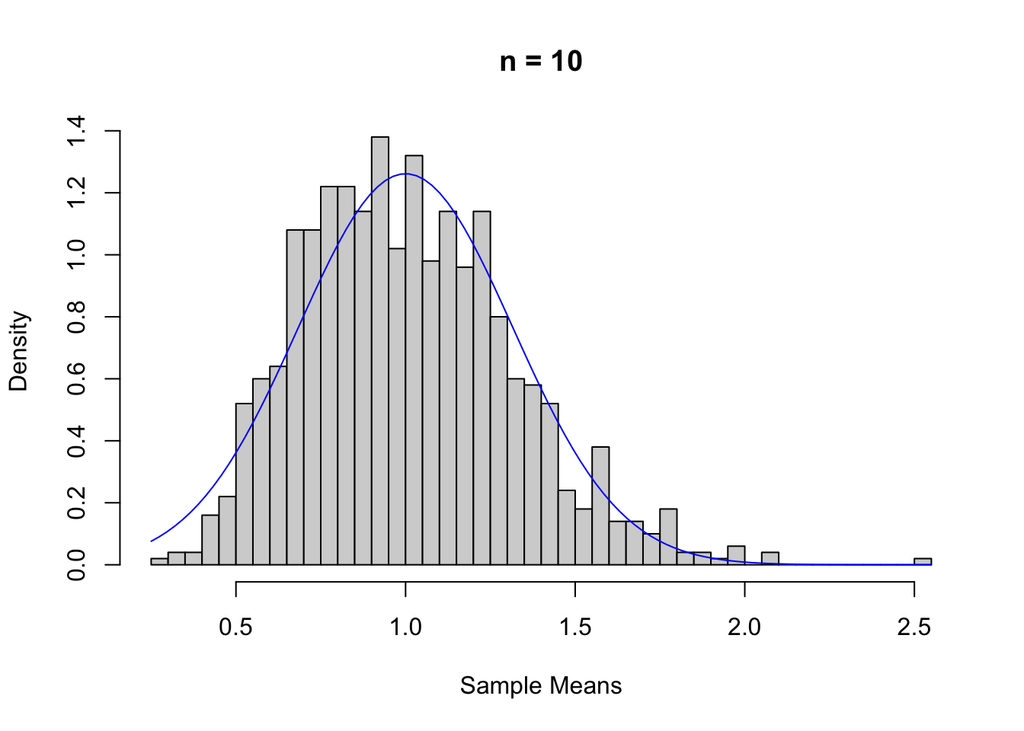

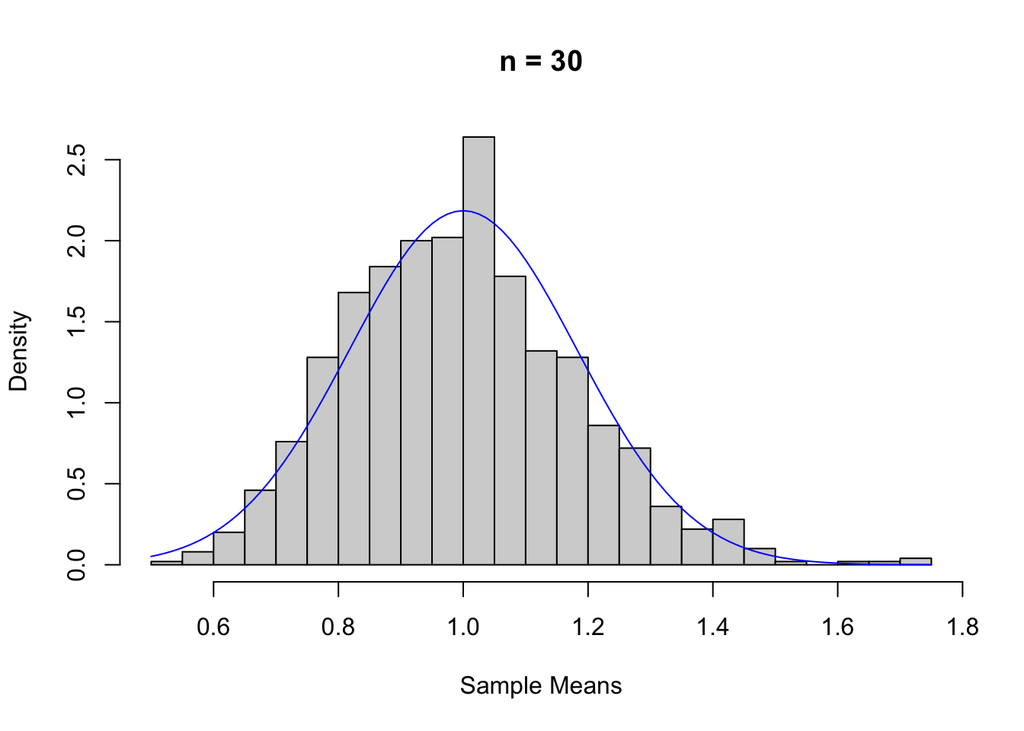

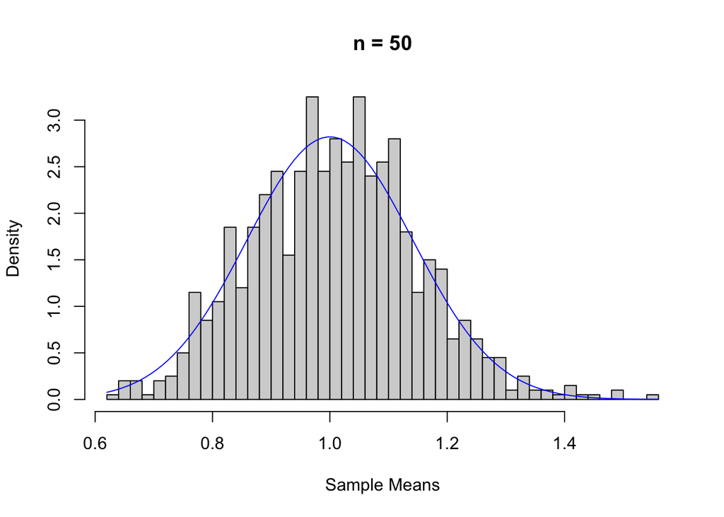

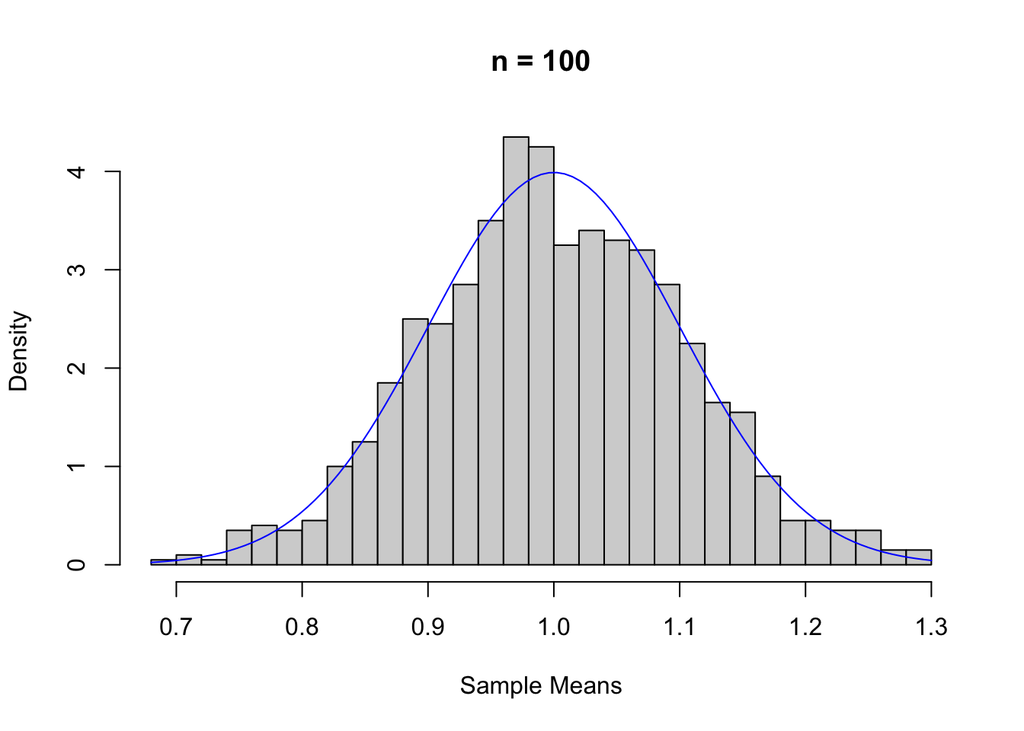

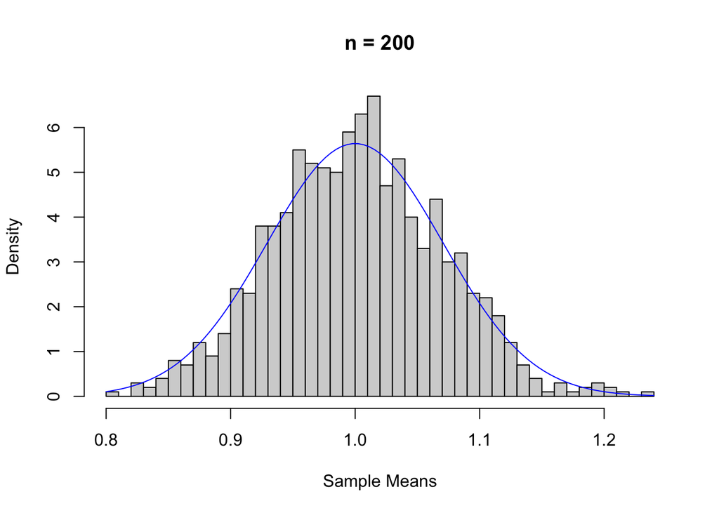

```r
for (n in sample_size) {
  means <- replicate(samples, mean(rexp(n, rate = lambda)))
  hist(means, probability = TRUE, main = paste("n =", n), xlab = "Sample Means", breaks = 40)
  curve(dnorm(x, mean = 1/lambda, sd = sqrt(1 / (lambda^2 * n))), add = TRUE, col = "blue")
}
```